# High School Seniors t Test

```r
library(tidyverse)
library(DT)
library(pander)
library(readr)
library(mosaic)
library(car)
HSS <- read_csv("../../Data/HighSchoolSeniors.csv")
#Remember: select "Session, Set Working Directory, To Source File Location", and then play this R-chunk into your console to read the HSS data into R.
```

## Background

In the small town of Cheney, Washington, at Cheney High School, there is held the largest slap jack competition on earth. This competition is held the last day of school in June (the school fittingly picked a J month for Jack). This competition is more competitive than any other sport offered during the school year. Students start preparing from their elementary years to get a head start. The reason for this excessive preparation and competition is that if he/she wins, they’ll get their high school diploma (no matter the grades they have completed). The founder of Cheney, WA was the world’s greatest slap jack player, so, in honor and memory of him, this award is given to the winner.

It is the end of the school year in Cheney High School and it is the final round of slap jack for the high school diploma. A senior against a freshman. Unfortunately, the senior in his last match was wounded from a hard slap and broke his finger. The principal decided that to only be fair, another senior should replace him. The principal looks to the soccer and basketball teams for athletes with quick reactions. The principal favored the basketball team over the soccer team. Sadly, the freshman one, and got his diploma while the other senior had to keep passing his classes.

Did the principle make the best decision in choosing a basketball player for the final round?

In order to test this, an experiment will be conducted using the data about seniors favorite sports from the [U.S. Census at School Questionnaire](https://ww2.amstat.org/censusatschool/pdfs/C@SQuestionnaire.pdf) to see if the difference in mean reaction times between seniors who play soccer and basketball is different than zero.

Our null hypothesis and alternative hypothesis are:

$$H_0: \mu_\text{Basketball} = \mu_\text{Soccer}$$

$$H_a: \mu_\text{Basketball} \neq \mu_\text{Soccer}$$
Because our confidence level has been set as 95%, we will make our significance level
$$\alpha = 0.05$$

### Data

Below, I have provided the data of reaction times from 36 soccer and basketball players. Three data points have been omitted (two from the basketball players and one from the soccer players) because they were 5 seconds or more and would affect the display and understanding of the data. 5 seconds is an unreasonable and inordinate amount of time to wait before reacting. It is assumed that the data for both soccer and basketball players is normally distributed.

```r
ReactionTimesSoccer <- HSS %>%
  filter(Favourite_physical_activity=="Soccer") %>%
  select(c(Reaction_time))
ReactionTimesBasketball <- HSS %>%
  filter(Favourite_physical_activity=="Basketball") %>%
  select(c(Reaction_time))
ReactionTimesSoccer$Basketball<- ReactionTimesBasketball$Reaction_time
ReactionTimesSoccer$Soccer <- ReactionTimesSoccer$Reaction_time
ReactionTimesBasketballvsSoccer <- select(ReactionTimesSoccer,c(Basketball,Soccer))
ReactionTimesBasketballvsSoccer <-  filter(ReactionTimesBasketballvsSoccer, Basketball!=5.0000 & Basketball!=6.0000)
ReactionTimesBasketballvsSoccer <-  filter(ReactionTimesBasketballvsSoccer, Soccer!=5.0000)
View(ReactionTimesBasketballvsSoccer)
datatable(ReactionTimesBasketballvsSoccer, options=list(lengthMenu = c(3,10,30)), extensions="Responsive")
```

|  | Basketball | Soccer |
| --- | --- | --- |
| 1 | 0.285 | 0.365 |
| 2 | 0.516 | 0.3 |
| 3 | 0.38 | 0.383 |
| 4 | 0.506 | 0.329 |
| 5 | 0.552 | 0.307 |
| 6 | 0.576 | 0.78 |
| 7 | 0.37 | 0.348 |
| 8 | 0.623 | 0.525 |
| 9 | 0.374 | 0.552 |
| 10 | 0.25 | 0.396 |

[output cut: 26 more lines]

## Analysis

These two box plots below will show us where the min, median, and max of the data is for both basketball and soccer. After the box plots, I added a 5 number summary which shows the exact values of what is being represented in the box plots.

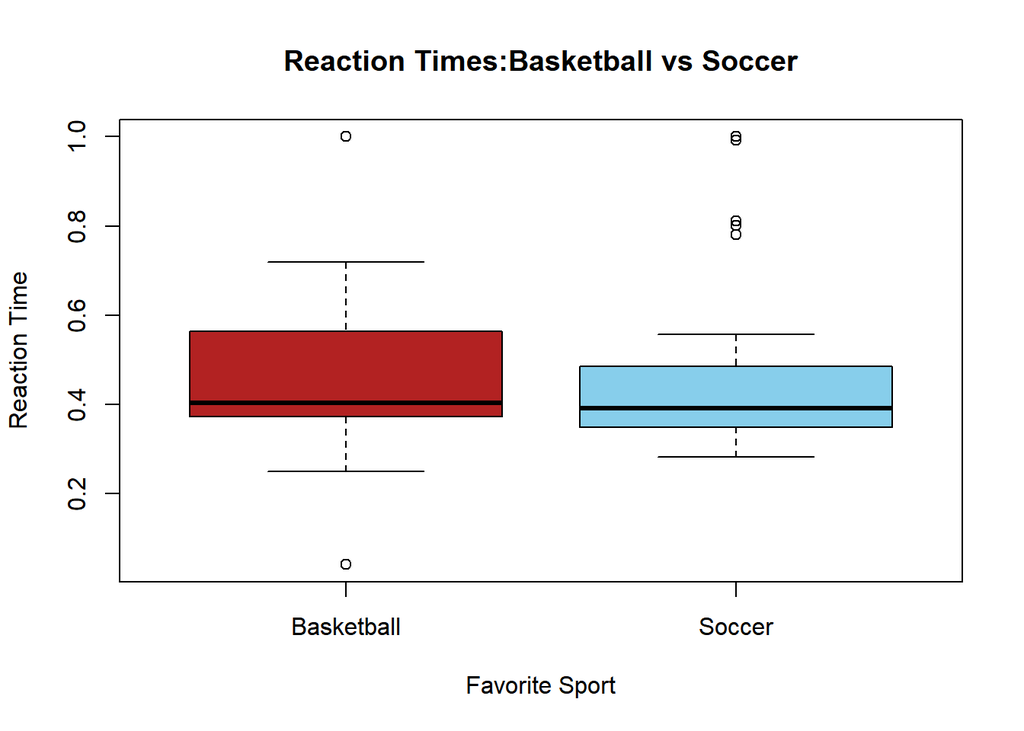

```r
boxplot(ReactionTimesBasketballvsSoccer, col=c("firebrick","skyblue"), xlab="Favorite Sport", ylab="Reaction Time", main="Reaction Times:Basketball vs Soccer")
```

```r
library(mosaic)
```

#### Basketball Players 5 Number Summary

```r
pander(fav_stats(ReactionTimesBasketballvsSoccer$Basketball))
```

| min | Q1 | median | Q3 | max | mean | sd | n | missing |
| --- | --- | --- | --- | --- | --- | --- | --- | --- |
| 0.0417 | 0.3737 | 0.4035 | 0.558 | 1 | 0.4601 | 0.1657 | 36 | 0 |

#### Soccer Players 5 Number Summary

```r
pander(fav_stats(ReactionTimesBasketballvsSoccer$Soccer))
```

| min | Q1 | median | Q3 | max | mean | sd | n | missing |
| --- | --- | --- | --- | --- | --- | --- | --- | --- |
| 0.282 | 0.3502 | 0.391 | 0.4822 | 1 | 0.4584 | 0.1867 | 36 | 0 |

Since we cannot draw a solid conclusion from this data we will have to use a statistical test to have a satisfactory inference for this data and to generalize our findings for other populations if possible.

### Independent Sample T-Test

We conducted the independent sample t-test and found these results:

```r
pander(t.test(ReactionTimesBasketballvsSoccer$Basketball, ReactionTimesBasketballvsSoccer$Soccer, mu=0, alternative="two.sided", conf.level=0.95))
```

Welch Two Sample t-test: `ReactionTimesBasketballvsSoccer$Basketball` and `ReactionTimesBasketballvsSoccer$Soccer`

| Test statistic | df | P value | Alternative hypothesis | mean of x | mean of y |
| --- | --- | --- | --- | --- | --- |
| 0.04186 | 69.03 | 0.9667 | two.sided | 0.4601 | 0.4584 |

### QQ-Plot

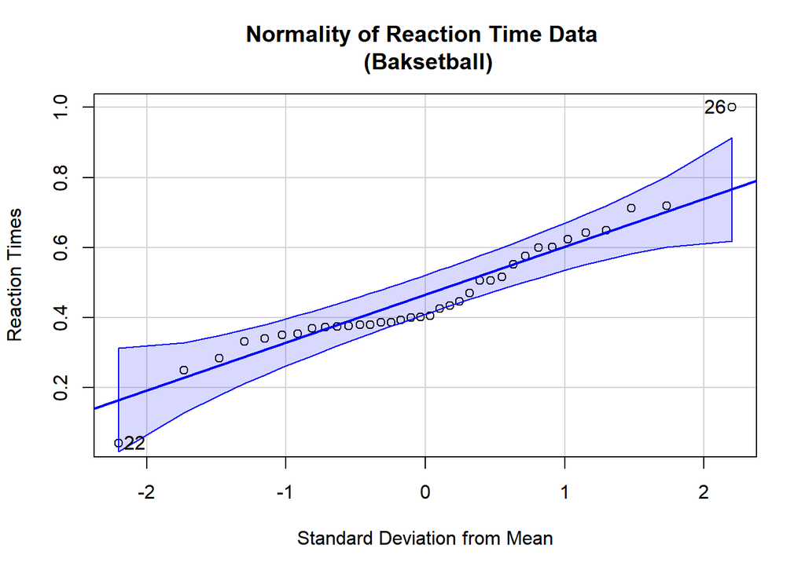

```
## [1] 26 22
```

```r
qqPlot(ReactionTimesBasketballvsSoccer$Basketball, xlab="Standard Deviation from Mean", ylab ="Reaction Times", main="Normality of Reaction Time Data \n (Baksetball)")
```

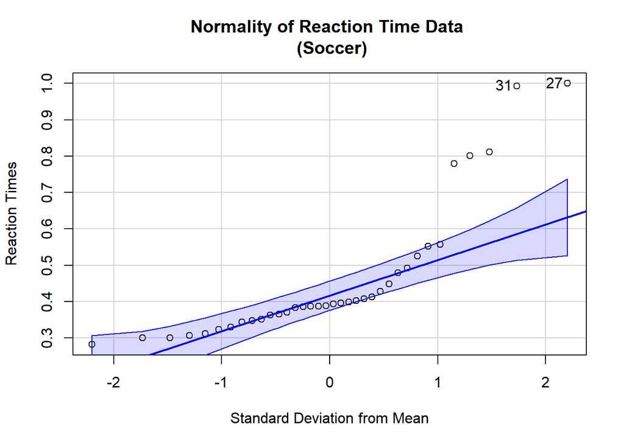

```
## [1] 27 31
```

```r
qqPlot(ReactionTimesBasketballvsSoccer$Soccer,xlab="Standard Deviation from Mean", ylab ="Reaction Times", main="Normality of Reaction Time Data \n (Soccer)")
```

## Interpretation

Because we have found that the $p-value$ is very close to 1 (.9667), we believe the null hypothesis to be true and that there is no significant difference between reaction times of basketball players vs soccer players. This being said, the data is not completely normal and if it were, may have resulted in a different inference.

If the data were normal, we could infer more confidently that the principal could have chosen either team to play the last match and still would have lost knowing that soccer players do not differ significantly in reaction times with basketball players.

After further consideration, my conclusion may not be very accurate due to the fact that the data from the U.S. Census at School Questionnaire asked for students’ favorite sport rather than which sport are they best at. Someone whose favorite sport is soccer may not be very good at it. It would be in our best interest to create another experiment that asked for the sport that they were best at. This might give us more reliable and accurate data to reach a more satisfying conclusion.